# O que os novos prefeitos encontrarão nos cofres municipais?

Índice de Gestão Fiscal Municipal - IGFM

[Fernando da Silva](https://github.com/schoulten)[^1]

03 de dezembro de 2020

# Introdução

5.570 novos prefeitos foram eleitos, em um contexto e campanha ainda dominamos pela pandemia da Covid-19, e tomarão posse no próximo 1º de janeiro com muitos velhos desafios. Com o que irão se deparar nas prefeituras?

Nosso país passa por um momento crítico em suas contas públicas. Estamos há quase 6 anos registrando consecutivos déficits primários - quando as despesas primárias superam a receita primária líquida -, período no qual a trajetória da dívida pública federal cresceu explosivamente e estados e municípios declararam insolvência. No contexto municipal, observa-se que muitas prefeituras possuem pouca capacidade de gerar receita para financiar até mesmo sua estrutura administrativa, constituindo-se um desafio vital para a gestão fiscal dos municípios brasileiros.

Para visualizar esse problema construímos o Índice de Gestão Fiscal Municipal – IGFM, que mede a capacidade dos municípios brasileiros se sustentarem em um intervalo de 0 a 1, adaptado da metodologia da Firjan. São consideradas no cálculo do índice as receitas provenientes da atividade econômica municipal e as despesas para manter a Câmara de Vereadores e a estrutura administrativa da Prefeitura, de forma que quanto mais próximo de zero estiver o IGFM do município menor é a capacidade do mesmo gerar receitas e arcar com os custos de sua própria existência.

# Mapa do IGFM

No mapa constam os resultados do IGFM categorizados em 4 níveis de situação: crítica, difícil, boa e excelente. Podemos observar que 2.415 prefeituras (44,4% do total) estão em situação crítica e difícil, ou seja, não conseguem gerar receita suficiente para custear a própria estrutura administrativa. A maior parcela desse número é composta por municípios pequenos, concentrados nas regiões Norte e Nordeste, nos quais a população média não passa de 14 mil pessoas.

Esse resultado evidencia uma grande ineficiência na administração dos recursos públicos. Nesse contexto, propostas de reforma administrativa vêm sendo debatidas e indicadores como esses são importantes para entender o problema.

É fundamental discutir e propor soluções para fatores como esse, caso contrário este mapa mostrará um Brasil cada vez mais crítico.

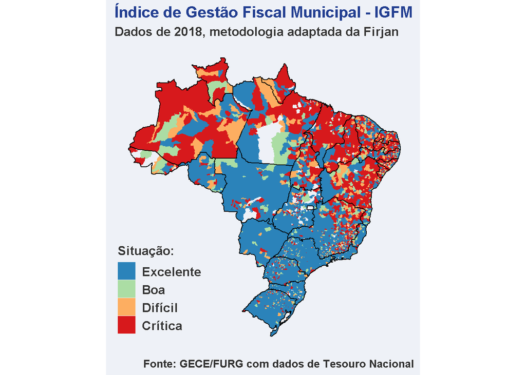

[^1]: Grupo de Estudos de Conjuntura Econômica - fernando@gecefurg.com.br